# Tutorial - Google Colab

Aprender conceptos básicos de Google Colab.

jupyter-notebooks

Autor/a

Valeska Canales

Fecha de publicación

9 de julio de 2024

[figure not shown]

# ¡Bienvenido a Colab!

## Explora la API de Gemini

La API de Gemini te da acceso a los modelos de Gemini creados por Google DeepMind. Los modelos de Gemini están diseñados desde cero para ser multimodales, lo que te permite razonar de manera fluida a través de texto, imágenes, código y audio.

**Cómo empezar**

1. Ve a [Google AI Studio](https://aistudio.google.com/) e inicia sesión con tu cuenta de Google.
2. [Crea una clave de API](https://aistudio.google.com/app/apikey).
3. Utiliza un inicio rápido para [Python](https://colab.research.google.com/github/google-gemini/cookbook/blob/main/quickstarts/Prompting.ipynb), o llama a la API REST usando [curl](https://colab.research.google.com/github/google-gemini/cookbook/blob/main/quickstarts/rest/Prompting_REST.ipynb).

**Explora casos de uso**

- [Crea una campaña de marketing](https://colab.research.google.com/github/google-gemini/cookbook/blob/main/examples/Market_a_Jet_Backpack.ipynb)
- [Analiza grabaciones de audio](https://colab.research.google.com/github/google-gemini/cookbook/blob/main/quickstarts/Audio.ipynb)
- [Usa instrucciones del sistema en chat](https://colab.research.google.com/github/google-gemini/cookbook/blob/main/quickstarts/System_instructions.ipynb)

Para aprender más, consulta el [Gemini cookbook](https://github.com/google-gemini/cookbook) o visita la [documentación de la API de Gemini](https://ai.google.dev/docs/).

> 🔑 **Nota**: Para profundizar en Google Colab, se recomienda visitar la [página oficial de Google Colab](https://colab.research.google.com/).

Colab ahora tiene funciones de IA impulsadas por [Gemini](https://gemini.google.com). El video a continuación proporciona información sobre cómo usar estas funciones, ya seas nuevo en Python o un veterano experimentado.

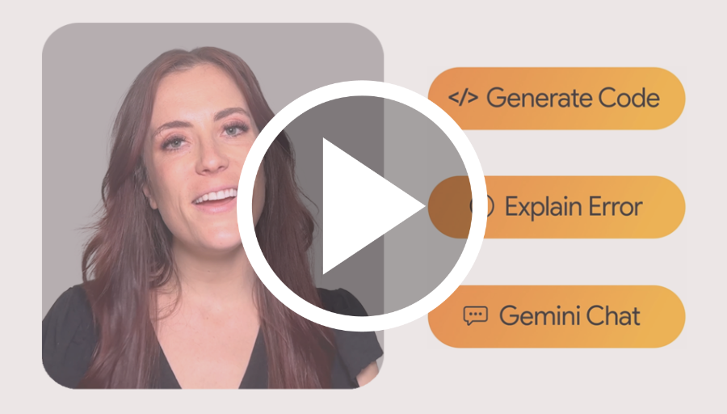

## ¿Qué es Colab?

Colab, o “Colaboratory”, te permite escribir y ejecutar Python en tu navegador, con: - Configuración cero requerida - Acceso gratuito a GPUs - Compartición sencilla

Ya seas **estudiante**, **científico de datos** o **investigador en IA**, Colab puede facilitar tu trabajo. Mira [Introducción a Colab](https://www.youtube.com/watch?v=inN8seMm7UI) o [Características de Colab que Quizás No Conocías](https://www.youtube.com/watch?v=rNgswRZ2C1Y) para aprender más, o simplemente comienza a trabajar a continuación.

## **Cómo empezar**

El documento que estás leyendo no es una página web estática, sino un entorno interactivo llamado **cuaderno de Colab** que te permite escribir y ejecutar código.

Por ejemplo, aquí hay una **celda de código** con un breve script en Python que calcula un valor, lo almacena en una variable y muestra el resultado:

```python
seconds_in_a_day = 24 * 60 * 60
seconds_in_a_day
```

```
86400
```

Para ejecutar el código en la celda anterior, selecciónala con un clic y luego presiona el botón de reproducción a la izquierda del código, o usa el atajo de teclado “Command/Ctrl+Enter”. Para editar el código, solo haz clic en la celda y comienza a editar.

Las variables que defines en una celda pueden ser utilizadas más adelante en otras celdas:

```python
seconds_in_a_week = 7 * seconds_in_a_day
seconds_in_a_week
```

```
604800
```

Los cuadernos de Colab te permiten combinar **código ejecutable** y **texto enriquecido** en un solo documento, junto con **imágenes**, **HTML**, **LaTeX** y más. Cuando creas tus propios cuadernos de Colab, se almacenan en tu cuenta de Google Drive. Puedes compartir fácilmente tus cuadernos de Colab con compañeros de trabajo o amigos, permitiéndoles comentar en tus cuadernos o incluso editarlos. Para aprender más, consulta Resumen de Colab. Para crear un nuevo cuaderno de Colab, puedes usar el menú de Archivo arriba o usar el siguiente enlace: [crear un nuevo cuaderno de Colab](http://colab.research.google.com#create=true).

Los cuadernos de Colab son cuadernos Jupyter que están alojados por Colab. Para obtener más información sobre el proyecto Jupyter, visita jupyter.org.